# Azenta ChIP-Seq Project Report

- Project Summary
- Description of Workflow
- Analysis
- Deliverables

# Azenta ChIP-Seq Project Report

## 1. Project Summary

| Customer | Anders Ohman |
| --- | --- |
| QuoteNumber | 30-858293328 |
| Configuration |  |

## 2. Description of Workflow

### 2.1 Bioinformatics analysis workflow

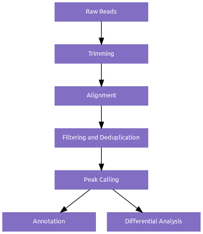

Figure 2.1 Bioinformatics workflow

## 3. Data Analysis

### 3.1 Sequencing statistics

Raw BCL files generated by the sequencer were converted to FASTQ files for each sample using bcf2fastq v2.19. Table 3.1 summarizes sequencing statistics for each sample and table 3.2 summarizes sequencing statistics for all samples.

| Project | Sample ID | Barcode Sequence | # Reads | Yield (Mbases) | Mean Quality Score | % Bases >= 30 |
| --- | --- | --- | --- | --- | --- | --- |
| 30-858293328 | TA1-2m1 | TAAGGCGA+GCGATCTA | 11395774 | 3419 | 34.32 | 85.15 |
| 30-858293328 | TF2-2m1 | TCCTGAGC+GCGATCTA | 7966963 | 2390 | 34.12 | 83.93 |
| 30-858293328 | TA1-3m1 | TAAGGCGA+AGAGGATA | 22741899 | 6823 | 34.98 | 89.11 |
| 30-858293328 | TA2-3m2 | CGTACTAG+TCTACTCT | 36585626 | 10976 | 35.29 | 90.45 |
| 30-858293328 | TF1-2m3 | AGGCAGAA+ATAGAGAG | 51593340 | 15478 | 34.65 | 87.41 |
| 30-858293328 | TA2-2m1 | CGTACTAG+GCGATCTA | 28503454 | 8551 | 34.73 | 87.21 |
| 30-858293328 | TF2-3m1 | TCCTGAGC+AGAGGATA | 33223968 | 9967 | 35.35 | 90.74 |
| 30-858293328 | TF1-2m1 | AGGCAGAA+GCGATCTA | 30848135 | 9254 | 34.91 | 88.34 |
| 30-858293328 | TF1-3m1 | AGGCAGAA+AGAGGATA | 45738169 | 13721 | 34.96 | 88.92 |
| 30-858293328 | TF2-3m2 | TCCTGAGC+TCTACTCT | 27627416 | 8288 | 35.13 | 89.64 |

[output cut: 6 more lines]

| Project | # Reads | Yield (Mbases) | Mean Quality Score | % Bases >= 30 |
| --- | --- | --- | --- | --- |
| 30-858293328 | 508826753 | 152649 | 35 | 89.03 |

### 3.2 Alignment and post-processing

#### 3.2.1 Alignment Statistics

Sequencing adapters and low-quality bases were trimmed using Trimmomatic 0.38. Cleaned reads were then aligned to the reference genome /azngsfs/gwngs/data/projects/30-858293328/Rat-v6.cfg using bowtie2. Table 3.3 summarizes alignment statistics for all samples.

| Sample | Read pairs after trimming | Read pairs concordantly aligned 1 time | Read pairs concordantly aligned >1 times | Singleton aligned 1 time | Singleton aligned >1 times | Overall alignment rate |
| --- | --- | --- | --- | --- | --- | --- |
| TA1-2m1 | 11355988 | 7226240 | 2225580 | 149592 | 66616 | 84.25 |
| TA1-2m3 | 29089071 | 19508464 | 6235230 | 657396 | 289760 | 90.21 |
| TA1-3m1 | 22648048 | 13978421 | 4437503 | 370423 | 165973 | 82.57 |
| TA1-3m2 | 50780014 | 26383245 | 7976331 | 883285 | 382144 | 68.98 |
| TA2-2m1 | 28417640 | 19002017 | 5908770 | 332017 | 142540 | 88.56 |
| TA2-2m3 | 32955333 | 22787917 | 6971414 | 549130 | 230918 | 91.56 |
| TA2-3m1 | 19339609 | 13487793 | 4166837 | 263979 | 115932 | 92.34 |
| TA2-3m2 | 36418282 | 8313683 | 2586700 | 256066 | 113449 | 30.47 |
| TF1-2m1 | 30772961 | 21369774 | 6646657 | 583350 | 252204 | 92.47 |
| TF1-2m3 | 51290230 | 35770400 | 10836226 | 2028182 | 797766 | 93.72 |

[output cut: 6 more lines]

#### 3.2.2 Filtering and Deduplication

Aligned reads were filtered using samtools 1.9 to keep alignments that (1) have a minimum mapping quality of 30, (2) are aligned concordantly, and (3) are the primary-called alignments. PCR or optical duplicates were marked using Picard 2.18.26 and removed. Prior to peak calling, reads mapping to mitochondria (mt) were called and filtered and reads mapping to unplaced contigs were removed. Table 3.4 summarizes the read cleanup statistics.

| Sample | Aligned read pairs after quality filtering | Read pairs after deduplication | % Duplicates | Deduplicated read pairs mapped to mitochondria | % Mitochondria contents | Read pairs for analysis |
| --- | --- | --- | --- | --- | --- | --- |
| TA1-2m1 | 7194721 | 647966 | 0.909938689769902 | 3468 | 0.00535213267362794 | 640242 |
| TA1-2m3 | 19562376 | 1373790 | 0.929773867959597 | 6291 | 0.00457930251348459 | 1357329 |
| TA1-3m1 | 14139429 | 1187991 | 0.915980270490414 | 4940 | 0.00415828066037537 | 1174609 |
| TA1-3m2 | 26312166 | 771140 | 0.970692644611622 | 3129 | 0.0040576289649091 | 763025 |
| TA2-2m1 | 19253717 | 639777 | 0.96677124733889 | 2764 | 0.00432025533896967 | 632840 |
| TA2-2m3 | 23162413 | 1184379 | 0.948866337889753 | 5014 | 0.00423344216673886 | 1170706 |
| TA2-3m1 | 13744275 | 1017460 | 0.925972086559677 | 3864 | 0.0037976922925717 | 1006419 |
| TA2-3m2 | 8340648 | 730812 | 0.912379469796591 | 2710 | 0.00370820402511179 | 723381 |
| TF1-2m1 | 21496406 | 981318 | 0.954349671289238 | 4559 | 0.00464579269920658 | 970248 |
| TF1-2m3 | 35327902 | 1533018 | 0.95660602772279 | 6800 | 0.00443569481897799 | 1515362 |

[output cut: 6 more lines]

### 3.3 Peak calling and differential analysis

#### 3.3.1 Peak calling results for samples and groups

MACS2 2.1.2 was used for peak calling to identify open chromatin regions. If a blacklist of artefactual regions (areas with extremely high or low-mappability) was available for the provided reference genome, called peaks were filtered for these regions to mitigate errors due to mappability. Valid peaks from each group or condition were merged and peaks called in at least 66% of samples were kept for downstream analyses. Table 3.5 summarizes peak calling results.

| Condition | Sample | Number of Peaks |
| --- | --- | --- |
| I | TA1-2m1 | 302 |
| I | TA1-2m3 | 1456 |
| I | TA1-3m1 | 906 |
| I | TA1-3m2 | 1254 |
| I | Merged | 10 |
| J | TF1-2m1 | 831 |
| J | TF1-2m3 | 2729 |
| J | TF1-3m1 | 2337 |
| J | TF1-3m2 | 981 |
| J | Merged | 28 |

[output cut: 34 more lines]

#### 3.3.2 Differential peak analyses summary

For each pair-wise comparison, peaks from condition A and condition B were merged and peaks found in either condition were kept for downstream analyses. Reads falling beneath peaks were counted in all samples and these counts were used for differential peak analyses using the R package Diffbind. Table 3.6 summarizes the differential peak calling results.

| Comparison | Control | Experiment | Total | Lower Affinity | Higher Affinity |
| --- | --- | --- | --- | --- | --- |
| TA-2m1.vs.TA-3m1 | TA-2m1 | TA-3m1 | 10 | 10 | 0 |
| TA-2m1.vs.TA-3m2 | TA-2m1 | TA-3m2 | 32 | 23 | 9 |
| TA-2m1.vs.TF-2m1 | TA-2m1 | TF-2m1 | 6 | 0 | 6 |
| TA-2m1.vs.TF-2m3 | TA-2m1 | TF-2m3 | 58 | 58 | 0 |
| TA-2m1.vs.TF-3m1 | TA-2m1 | TF-3m1 | 95 | 40 | 55 |
| TA-2m1.vs.TF-3m2 | TA-2m1 | TF-3m2 | 63 | 50 | 13 |
| TA-2m3.vs.TA-3m1 | TA-2m3 | TA-3m1 | 0 | 0 | 0 |
| TA-2m3.vs.TA-3m2 | TA-2m3 | TA-3m2 | 27 | 4 | 23 |
| TA-2m3.vs.TF-2m1 | TA-2m3 | TF-2m1 | 10 | 4 | 6 |
| TA-2m3.vs.TF-2m3 | TA-2m3 | TF-2m3 | 0 | 0 | 0 |

[output cut: 17 more lines]

## 4. Deliverables

- 00_fastq: raw data
  - raw data in fastq format: *sample*_R1_001.fastq.gz *sample*_R2_001.fastq.gz
- alignment: aligned data
  - alignment file in bam format: *sample*.bam
- peakcalling: peaks called.
  - peaks for each sample: *sample*.filtered_peaks
  - peaks for each condition (with annotation): *group*.merged_peaks.bed.gz
- differential_analysis: differential peak analysis results
  - all peaks from the pairwise condidtions: *ctrl*.vs.*expt*.merged_peaks.bed.gz
  - differential analysis (all peaks with annotation): *ctrl*.vs.*expt*.annotated.peaks.csv.gz
- Azenta Life Sciences
- Next Generation Sequencing
- Email: ngs@azenta.com
- Phone: 908-222-0711 ext 1